# Instructor Notes: Untangling House Prices

The student handout contains some background on the data. That handout is presented as a contrast between analysis using one explanatory variable at a time and analysis using more than one explanatory variable simultaneously.

Students do not yet have the theory that they will need to understand how and why fitting a model with more than one explanatory variable simultaneous works. This activity is meant to set up the question, “Why should I believe one result rather than another?” In the student handout, that question is addressed by an appeal to authority: look to see what realtors and developers have to say about the value of a fireplace. Not very satisfactory, scientifically. After all, how do they know.

There are some other aspects of statistical modeling that the housing price setting can illuminate:

- Dealing with non-normal distributions by transformation
- “Untangling” of influences.
- Interaction terms

## Non-Normal Distributions

The price (and living area) variables have a right-skew form. In order to avoid the influence of the cases on the tails, and in order to render price into a more meaningful form, a log transformation can be appropriate.

In addition to changing the shape of the distribution, the log transformation changes the meaning of price into a proportional variable — an increase in log-price by one unit corresponds to a constant proportion change in price rather than a constant dollar change in price.

```r
houses = fetchData("SaratogaHouses.csv")
```

```
## Retrieving from http://www.mosaic-web.org/go/datasets/SaratogaHouses.csv
```

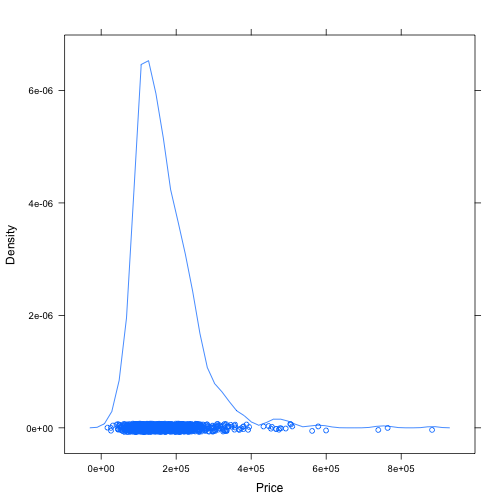

```r
densityplot(~Price, data = houses)
```

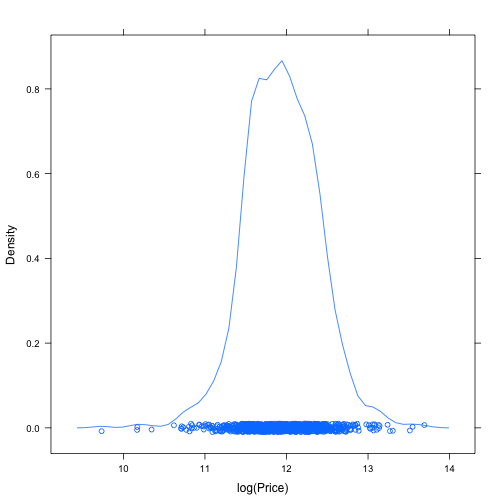

```r
densityplot(~log(Price), data = houses)
```

## Untangling

The figure shows a simple, theoretical and schematic diagram of some of the factors influencing house prices.

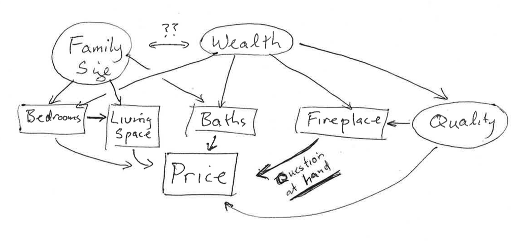

The quantities measured in the Saratoga house price dataset are drawn in boxes. Other factors, not measured, are shown in ovals.

The idea behind this diagram is that there are two background influences at work. (Of course, there may be many more! Make your own theory!) The background influences in this theory are

- Family Size
- Wealth

These two factors may or may not be connected, depending on whether you think family size influences wealth and/or vice versa. That possible connection is shown by a double-headed arrow with question marks.

The other arrows show other, plausible connections.

- A bigger family wants more living space and more bedrooms and baths.
- A wealthier family wants more of those things too. But they also want a higher “quality” house, including for example a fireplace.

The immediate question at hand in the student handout is how the presence of a fireplace influences price. It seems obvious that the way to study this is to examine the relationship between “Fireplace” and “Price”, the arrow marked as “Question at Hand.”

Note that there are many pathways between “Fireplace” and “Price”: quite a tangled network of influences. When you examine the relationship between two variables, you are studying all of the possible paths. (The analysis of such paths, and their use to select covariates in a model, is the subject of Chapter 17.) In particular, many of the paths from fireplace to price go through “Wealth” and “Quality”. If we want to study the influence of a fireplace on price, we need to untangle these various influences.

## Interaction

There's a temptation when building a model for an untrained audience to stick to a “main effects” form, without interaction terms. Such a model makes it easy to say, “This is the effect of variable A, and this is the effect of variable B.” In the house price example, this style shows up when saying, “A second bathroom is worth this much, an additional bedroom is worth this much, and an additional square foot of living area is worth this much.” That may well be a fine approximation for the purposes of conveying information simply.

In the house price example, however, there is a strong potential for an interaction. The number of bedrooms is not independent of the living area. You can add a bedroom to a house by taking away some of the common living space. Or you can add a bedroom by dividing in half an existing bedroom. Neither of these approaches to adding a bedroom could be expected to increase the price of a house as much as adding a bedroom that contains additional space.

This suggests that there should be an interaction between living space and number of bedrooms: the effect on price of an additional bedroom depends on how much living space there is.

You can explore this with the `vLM` program, watching how \( R^2 \) changes as you include and exclude the interaction terms.